# Bikeshare

Pyimoe Than

6/17/2022

##Business problem

How do annual members and casual riders use Cyclistic bikes differently?

## Importing library

```r
library(dplyr)
```

```r
library(writexl)
library(tidyr)
library(ggplot2)
library(tidyverse)
library(data.table)
library(lubridate)#for datetime object
```

## Load the data

```r
Bike_Share_202004=read.csv("202004-divvy-tripdata.csv",header=T)
Bike_Share_202005=read.csv("202005-divvy-tripdata.csv",header=T)
Bike_Share_202006=read.csv("202006-divvy-tripdata.csv",header=T)
Bike_Share_202007=read.csv("202007-divvy-tripdata.csv",header=T)
Bike_Share_202008=read.csv("202008-divvy-tripdata.csv",header=T)
Bike_Share_202009=read.csv("202009-divvy-tripdata.csv",header=T)
Bike_Share_202010=read.csv("202010-divvy-tripdata.csv",header=T)
Bike_Share_202011=read.csv("202011-divvy-tripdata.csv",header=T)
Bike_Share_202012=read.csv("202012-divvy-tripdata.csv",header=T)
```

## Total Number of Columns and Width

```r
dim(Bike_Share_202004)
```

```
## [1] 84776    13
```

```r
dim(Bike_Share_202005)
```

```
## [1] 200274     13
```

```r
dim(Bike_Share_202006)
```

```
## [1] 343005     13
```

```r
dim(Bike_Share_202007)
```

```
## [1] 551480     13
```

```r
dim(Bike_Share_202008)
```

```
## [1] 622361     13
```

```r
dim(Bike_Share_202009)
```

```
## [1] 532958     13
```

```r
dim(Bike_Share_202010)
```

```
## [1] 388653     13
```

```r
dim(Bike_Share_202011)
```

```
## [1] 259716     13
```

```r
dim(Bike_Share_202012)
```

```
## [1] 131573     13
```

## Check Column name of each dataset for consistency

```r
colnames(Bike_Share_202004)
```

```
##  [1] "ride_id"            "rideable_type"      "started_at"
##  [4] "ended_at"           "start_station_name" "start_station_id"
##  [7] "end_station_name"   "end_station_id"     "start_lat"
## [10] "start_lng"          "end_lat"            "end_lng"
## [13] "member_casual"
```

```r
colnames(Bike_Share_202005)
```

```
##  [1] "ride_id"            "rideable_type"      "started_at"
##  [4] "ended_at"           "start_station_name" "start_station_id"
##  [7] "end_station_name"   "end_station_id"     "start_lat"
## [10] "start_lng"          "end_lat"            "end_lng"
## [13] "member_casual"
```

```r
colnames(Bike_Share_202006)
```

```
##  [1] "ride_id"            "rideable_type"      "started_at"
##  [4] "ended_at"           "start_station_name" "start_station_id"
##  [7] "end_station_name"   "end_station_id"     "start_lat"
## [10] "start_lng"          "end_lat"            "end_lng"
## [13] "member_casual"
```

```r
colnames(Bike_Share_202007)
```

```
##  [1] "ride_id"            "rideable_type"      "started_at"
##  [4] "ended_at"           "start_station_name" "start_station_id"
##  [7] "end_station_name"   "end_station_id"     "start_lat"
## [10] "start_lng"          "end_lat"            "end_lng"
## [13] "member_casual"
```

```r
colnames(Bike_Share_202008)
```

```
##  [1] "ride_id"            "rideable_type"      "started_at"
##  [4] "ended_at"           "start_station_name" "start_station_id"
##  [7] "end_station_name"   "end_station_id"     "start_lat"
## [10] "start_lng"          "end_lat"            "end_lng"
## [13] "member_casual"
```

```r
colnames(Bike_Share_202009)
```

```
##  [1] "ride_id"            "rideable_type"      "started_at"
##  [4] "ended_at"           "start_station_name" "start_station_id"
##  [7] "end_station_name"   "end_station_id"     "start_lat"
## [10] "start_lng"          "end_lat"            "end_lng"
## [13] "member_casual"
```

```r
colnames(Bike_Share_202010)
```

```
##  [1] "ride_id"            "rideable_type"      "started_at"
##  [4] "ended_at"           "start_station_name" "start_station_id"
##  [7] "end_station_name"   "end_station_id"     "start_lat"
## [10] "start_lng"          "end_lat"            "end_lng"
## [13] "member_casual"
```

```r
colnames(Bike_Share_202011)
```

```
##  [1] "ride_id"            "rideable_type"      "started_at"
##  [4] "ended_at"           "start_station_name" "start_station_id"
##  [7] "end_station_name"   "end_station_id"     "start_lat"
## [10] "start_lng"          "end_lat"            "end_lng"
## [13] "member_casual"
```

```r
colnames(Bike_Share_202012)
```

```
##  [1] "ride_id"            "rideable_type"      "started_at"
##  [4] "ended_at"           "start_station_name" "start_station_id"
##  [7] "end_station_name"   "end_station_id"     "start_lat"
## [10] "start_lng"          "end_lat"            "end_lng"
## [13] "member_casual"
```

## What kinds of Data we have in the dataset

```r
str(Bike_Share_202004)
```

```
## 'data.frame':    84776 obs. of  13 variables:
##  $ ride_id           : chr  "A847FADBBC638E45" "5405B80E996FF60D" "5DD24A79A4E006F4" "2A59BBDF5CDBA725" ...
##  $ rideable_type     : chr  "docked_bike" "docked_bike" "docked_bike" "docked_bike" ...
##  $ started_at        : chr  "2020-04-26 17:45:14" "2020-04-17 17:08:54" "2020-04-01 17:54:13" "2020-04-07 12:50:19" ...
##  $ ended_at          : chr  "2020-04-26 18:12:03" "2020-04-17 17:17:03" "2020-04-01 18:08:36" "2020-04-07 13:02:31" ...
##  $ start_station_name: chr  "Eckhart Park" "Drake Ave & Fullerton Ave" "McClurg Ct & Erie St" "California Ave & Division St" ...
##  $ start_station_id  : int  86 503 142 216 125 173 35 434 627 377 ...
##  $ end_station_name  : chr  "Lincoln Ave & Diversey Pkwy" "Kosciuszko Park" "Indiana Ave & Roosevelt Rd" "Wood St & Augusta Blvd" ...
##  $ end_station_id    : int  152 499 255 657 323 35 635 382 359 508 ...
##  $ start_lat         : num  41.9 41.9 41.9 41.9 41.9 ...
##  $ start_lng         : num  -87.7 -87.7 -87.6 -87.7 -87.6 ...
##  $ end_lat           : num  41.9 41.9 41.9 41.9 42 ...
##  $ end_lng           : num  -87.7 -87.7 -87.6 -87.7 -87.7 ...
##  $ member_casual     : chr  "member" "member" "member" "member" ...
```

```r
str(Bike_Share_202005)
```

```
## 'data.frame':    200274 obs. of  13 variables:
##  $ ride_id           : chr  "02668AD35674B983" "7A50CCAF1EDDB28F" "2FFCDFDB91FE9A52" "58991CF1DB75BA84" ...
##  $ rideable_type     : chr  "docked_bike" "docked_bike" "docked_bike" "docked_bike" ...
##  $ started_at        : chr  "2020-05-27 10:03:52" "2020-05-25 10:47:11" "2020-05-02 14:11:03" "2020-05-02 16:25:36" ...
##  $ ended_at          : chr  "2020-05-27 10:16:49" "2020-05-25 11:05:40" "2020-05-02 15:48:21" "2020-05-02 16:39:28" ...
##  $ start_station_name: chr  "Franklin St & Jackson Blvd" "Clark St & Wrightwood Ave" "Kedzie Ave & Milwaukee Ave" "Clarendon Ave & Leland Ave" ...
##  $ start_station_id  : int  36 340 260 251 261 206 261 180 331 219 ...
##  $ end_station_name  : chr  "Wabash Ave & Grand Ave" "Clark St & Leland Ave" "Kedzie Ave & Milwaukee Ave" "Lake Shore Dr & Wellington Ave" ...
##  $ end_station_id    : int  199 326 260 157 206 22 261 180 300 305 ...
##  $ start_lat         : num  41.9 41.9 41.9 42 41.9 ...
##  $ start_lng         : num  -87.6 -87.6 -87.7 -87.7 -87.7 ...
##  $ end_lat           : num  41.9 42 41.9 41.9 41.8 ...
##  $ end_lng           : num  -87.6 -87.7 -87.7 -87.6 -87.6 ...
##  $ member_casual     : chr  "member" "casual" "casual" "casual" ...
```

```r
str(Bike_Share_202006)
```

```
## 'data.frame':    343005 obs. of  13 variables:
##  $ ride_id           : chr  "8CD5DE2C2B6C4CFC" "9A191EB2C751D85D" "F37D14B0B5659BCF" "C41237B506E85FA1" ...
##  $ rideable_type     : chr  "docked_bike" "docked_bike" "docked_bike" "docked_bike" ...
##  $ started_at        : chr  "2020-06-13 23:24:48" "2020-06-26 07:26:10" "2020-06-23 17:12:41" "2020-06-20 01:09:35" ...
##  $ ended_at          : chr  "2020-06-13 23:36:55" "2020-06-26 07:31:58" "2020-06-23 17:21:14" "2020-06-20 01:28:24" ...
##  $ start_station_name: chr  "Wilton Ave & Belmont Ave" "Federal St & Polk St" "Daley Center Plaza" "Broadway & Cornelia Ave" ...
##  $ start_station_id  : int  117 41 81 303 327 327 41 115 338 84 ...
##  $ end_station_name  : chr  "Damen Ave & Clybourn Ave" "Daley Center Plaza" "State St & Harrison St" "Broadway & Berwyn Ave" ...
##  $ end_station_id    : int  163 81 5 294 117 117 81 303 164 53 ...
##  $ start_lat         : num  41.9 41.9 41.9 41.9 41.9 ...
##  $ start_lng         : num  -87.7 -87.6 -87.6 -87.6 -87.7 ...
##  $ end_lat           : num  41.9 41.9 41.9 42 41.9 ...
##  $ end_lng           : num  -87.7 -87.6 -87.6 -87.7 -87.7 ...
##  $ member_casual     : chr  "casual" "member" "member" "casual" ...
```

```r
str(Bike_Share_202007)
```

```
## 'data.frame':    551480 obs. of  13 variables:
##  $ ride_id           : chr  "762198876D69004D" "BEC9C9FBA0D4CF1B" "D2FD8EA432C77EC1" "54AE594E20B35881" ...
##  $ rideable_type     : chr  "docked_bike" "docked_bike" "docked_bike" "docked_bike" ...
##  $ started_at        : chr  "2020-07-09 15:22:02" "2020-07-24 23:56:30" "2020-07-08 19:49:07" "2020-07-17 19:06:42" ...
##  $ ended_at          : chr  "2020-07-09 15:25:52" "2020-07-25 00:20:17" "2020-07-08 19:56:22" "2020-07-17 19:27:38" ...
##  $ start_station_name: chr  "Ritchie Ct & Banks St" "Halsted St & Roscoe St" "Lake Shore Dr & Diversey Pkwy" "LaSalle St & Illinois St" ...
##  $ start_station_id  : int  180 299 329 181 268 635 113 211 176 31 ...
##  $ end_station_name  : chr  "Wells St & Evergreen Ave" "Broadway & Ridge Ave" "Clark St & Wellington Ave" "Clark St & Armitage Ave" ...
##  $ end_station_id    : int  291 461 156 94 301 289 140 31 191 142 ...
##  $ start_lat         : num  41.9 41.9 41.9 41.9 41.9 ...
##  $ start_lng         : num  -87.6 -87.6 -87.6 -87.6 -87.6 ...
##  $ end_lat           : num  41.9 42 41.9 41.9 41.9 ...
##  $ end_lng           : num  -87.6 -87.7 -87.6 -87.6 -87.6 ...
##  $ member_casual     : chr  "member" "member" "casual" "casual" ...
```

```r
str(Bike_Share_202008)
```

```
## 'data.frame':    622361 obs. of  13 variables:
##  $ ride_id           : chr  "322BD23D287743ED" "2A3AEF1AB9054D8B" "67DC1D133E8B5816" "C79FBBD412E578A7" ...
##  $ rideable_type     : chr  "docked_bike" "electric_bike" "electric_bike" "electric_bike" ...
##  $ started_at        : chr  "2020-08-20 18:08:14" "2020-08-27 18:46:04" "2020-08-26 19:44:14" "2020-08-27 12:05:41" ...
##  $ ended_at          : chr  "2020-08-20 18:17:51" "2020-08-27 19:54:51" "2020-08-26 21:53:07" "2020-08-27 12:53:45" ...
##  $ start_station_name: chr  "Lake Shore Dr & Diversey Pkwy" "Michigan Ave & 14th St" "Columbus Dr & Randolph St" "Daley Center Plaza" ...
##  $ start_station_id  : int  329 168 195 81 658 658 196 67 153 177 ...
##  $ end_station_name  : chr  "Clark St & Lincoln Ave" "Michigan Ave & 14th St" "State St & Randolph St" "State St & Kinzie St" ...
##  $ end_station_id    : int  141 168 44 47 658 658 49 229 225 305 ...
##  $ start_lat         : num  41.9 41.9 41.9 41.9 41.9 ...
##  $ start_lng         : num  -87.6 -87.6 -87.6 -87.6 -87.7 ...
##  $ end_lat           : num  41.9 41.9 41.9 41.9 41.9 ...
##  $ end_lng           : num  -87.6 -87.6 -87.6 -87.6 -87.7 ...
##  $ member_casual     : chr  "member" "casual" "casual" "casual" ...
```

```r
str(Bike_Share_202009)
```

```
## 'data.frame':    532958 obs. of  13 variables:
##  $ ride_id           : chr  "2B22BD5F95FB2629" "A7FB70B4AFC6CAF2" "86057FA01BAC778E" "57F6DC9A153DB98C" ...
##  $ rideable_type     : chr  "electric_bike" "electric_bike" "electric_bike" "electric_bike" ...
##  $ started_at        : chr  "2020-09-17 14:27:11" "2020-09-17 15:07:31" "2020-09-17 15:09:04" "2020-09-17 18:10:46" ...
##  $ ended_at          : chr  "2020-09-17 14:44:24" "2020-09-17 15:07:45" "2020-09-17 15:09:35" "2020-09-17 18:35:49" ...
##  $ start_station_name: chr  "Michigan Ave & Lake St" "W Oakdale Ave & N Broadway" "W Oakdale Ave & N Broadway" "Ashland Ave & Belle Plaine Ave" ...
##  $ start_station_id  : int  52 NA NA 246 24 94 291 NA NA NA ...
##  $ end_station_name  : chr  "Green St & Randolph St" "W Oakdale Ave & N Broadway" "W Oakdale Ave & N Broadway" "Montrose Harbor" ...
##  $ end_station_id    : int  112 NA NA 249 24 NA 256 NA NA NA ...
##  $ start_lat         : num  41.9 41.9 41.9 42 41.9 ...
##  $ start_lng         : num  -87.6 -87.6 -87.6 -87.7 -87.6 ...
##  $ end_lat           : num  41.9 41.9 41.9 42 41.9 ...
##  $ end_lng           : num  -87.6 -87.6 -87.6 -87.6 -87.6 ...
##  $ member_casual     : chr  "casual" "casual" "casual" "casual" ...
```

```r
str(Bike_Share_202010)
```

```
## 'data.frame':    388653 obs. of  13 variables:
##  $ ride_id           : chr  "ACB6B40CF5B9044C" "DF450C72FD109C01" "B6396B54A15AC0DF" "44A4AEE261B9E854" ...
##  $ rideable_type     : chr  "electric_bike" "electric_bike" "electric_bike" "electric_bike" ...
##  $ started_at        : chr  "2020-10-31 19:39:43" "2020-10-31 23:50:08" "2020-10-31 23:00:01" "2020-10-31 22:16:43" ...
##  $ ended_at          : chr  "2020-10-31 19:57:12" "2020-11-01 00:04:16" "2020-10-31 23:08:22" "2020-10-31 22:19:35" ...
##  $ start_station_name: chr  "Lakeview Ave & Fullerton Pkwy" "Southport Ave & Waveland Ave" "Stony Island Ave & 67th St" "Clark St & Grace St" ...
##  $ start_station_id  : int  313 227 102 165 190 359 313 125 NA 174 ...
##  $ end_station_name  : chr  "Rush St & Hubbard St" "Kedzie Ave & Milwaukee Ave" "University Ave & 57th St" "Broadway & Sheridan Rd" ...
##  $ end_station_id    : int  125 260 423 256 185 53 125 313 199 635 ...
##  $ start_lat         : num  41.9 41.9 41.8 42 41.9 ...
##  $ start_lng         : num  -87.6 -87.7 -87.6 -87.7 -87.7 ...
##  $ end_lat           : num  41.9 41.9 41.8 42 41.9 ...
##  $ end_lng           : num  -87.6 -87.7 -87.6 -87.7 -87.7 ...
##  $ member_casual     : chr  "casual" "casual" "casual" "casual" ...
```

```r
str(Bike_Share_202011)
```

```
## 'data.frame':    259716 obs. of  13 variables:
##  $ ride_id           : chr  "BD0A6FF6FFF9B921" "96A7A7A4BDE4F82D" "C61526D06582BDC5" "E533E89C32080B9E" ...
##  $ rideable_type     : chr  "electric_bike" "electric_bike" "electric_bike" "electric_bike" ...
##  $ started_at        : chr  "2020-11-01 13:36:00" "2020-11-01 10:03:26" "2020-11-01 00:34:05" "2020-11-01 00:45:16" ...
##  $ ended_at          : chr  "2020-11-01 13:45:40" "2020-11-01 10:14:45" "2020-11-01 01:03:06" "2020-11-01 00:54:31" ...
##  $ start_station_name: chr  "Dearborn St & Erie St" "Franklin St & Illinois St" "Lake Shore Dr & Monroe St" "Leavitt St & Chicago Ave" ...
##  $ start_station_id  : int  110 672 76 659 2 72 76 NA 58 394 ...
##  $ end_station_name  : chr  "St. Clair St & Erie St" "Noble St & Milwaukee Ave" "Federal St & Polk St" "Stave St & Armitage Ave" ...
##  $ end_station_id    : int  211 29 41 185 2 76 72 NA 288 273 ...
##  $ start_lat         : num  41.9 41.9 41.9 41.9 41.9 ...
##  $ start_lng         : num  -87.6 -87.6 -87.6 -87.7 -87.6 ...
##  $ end_lat           : num  41.9 41.9 41.9 41.9 41.9 ...
##  $ end_lng           : num  -87.6 -87.7 -87.6 -87.7 -87.6 ...
##  $ member_casual     : chr  "casual" "casual" "casual" "casual" ...
```

```r
str(Bike_Share_202012)
```

```
## 'data.frame':    131573 obs. of  13 variables:
##  $ ride_id           : chr  "70B6A9A437D4C30D" "158A465D4E74C54A" "5262016E0F1F2F9A" "BE119628E44F871E" ...
##  $ rideable_type     : chr  "classic_bike" "electric_bike" "electric_bike" "electric_bike" ...
##  $ started_at        : chr  "2020-12-27 12:44:29" "2020-12-18 17:37:15" "2020-12-15 15:04:33" "2020-12-15 15:54:18" ...
##  $ ended_at          : chr  "2020-12-27 12:55:06" "2020-12-18 17:44:19" "2020-12-15 15:11:28" "2020-12-15 16:00:11" ...
##  $ start_station_name: chr  "Aberdeen St & Jackson Blvd" "" "" "" ...
##  $ start_station_id  : chr  "13157" "" "" "" ...
##  $ end_station_name  : chr  "Desplaines St & Kinzie St" "" "" "" ...
##  $ end_station_id    : chr  "TA1306000003" "" "" "" ...
##  $ start_lat         : num  41.9 41.9 41.9 41.9 41.8 ...
##  $ start_lng         : num  -87.7 -87.7 -87.7 -87.7 -87.6 ...
##  $ end_lat           : num  41.9 41.9 41.9 41.9 41.8 ...
##  $ end_lng           : num  -87.6 -87.7 -87.7 -87.7 -87.6 ...
##  $ member_casual     : chr  "member" "member" "member" "member" ...
```

## Convert numeric ID into Categorical ID

```r
Bike_Share_202004$start_station_id=as.character(Bike_Share_202004$start_station_id)
Bike_Share_202004$end_station_id=as.character(Bike_Share_202004$end_station_id)

Bike_Share_202005$start_station_id=as.character(Bike_Share_202005$start_station_id)
Bike_Share_202005$end_station_id=as.character(Bike_Share_202005$end_station_id)

Bike_Share_202006$start_station_id=as.character(Bike_Share_202006$start_station_id)
Bike_Share_202006$end_station_id=as.character(Bike_Share_202006$end_station_id)


Bike_Share_202007$start_station_id=as.character(Bike_Share_202007$start_station_id)
Bike_Share_202007$end_station_id=as.character(Bike_Share_202007$end_station_id)

Bike_Share_202008$start_station_id=as.character(Bike_Share_202008$start_station_id)
Bike_Share_202008$end_station_id=as.character(Bike_Share_202008$end_station_id)

Bike_Share_202009$start_station_id=as.character(Bike_Share_202009$start_station_id)
Bike_Share_202009$end_station_id=as.character(Bike_Share_202009$end_station_id)

Bike_Share_202010$start_station_id=as.character(Bike_Share_202010$start_station_id)
Bike_Share_202010$end_station_id=as.character(Bike_Share_202010$end_station_id)

Bike_Share_202011$start_station_id=as.character(Bike_Share_202011$start_station_id)
Bike_Share_202011$end_station_id=as.character(Bike_Share_202011$end_station_id)

Bike_Share_202012$start_station_id=as.character(Bike_Share_202012$start_station_id)
Bike_Share_202012$end_station_id=as.character(Bike_Share_202012$end_station_id)
```

## Combine all data and make it all trips

```r
Trips=rbind(Bike_Share_202004,Bike_Share_202005,Bike_Share_202006,Bike_Share_202007,Bike_Share_202008,Bike_Share_202009,Bike_Share_202010,Bike_Share_202011,Bike_Share_202012)
str(Trips)
```

```
## 'data.frame':    3114796 obs. of  13 variables:
##  $ ride_id           : chr  "A847FADBBC638E45" "5405B80E996FF60D" "5DD24A79A4E006F4" "2A59BBDF5CDBA725" ...
##  $ rideable_type     : chr  "docked_bike" "docked_bike" "docked_bike" "docked_bike" ...
##  $ started_at        : chr  "2020-04-26 17:45:14" "2020-04-17 17:08:54" "2020-04-01 17:54:13" "2020-04-07 12:50:19" ...
##  $ ended_at          : chr  "2020-04-26 18:12:03" "2020-04-17 17:17:03" "2020-04-01 18:08:36" "2020-04-07 13:02:31" ...
##  $ start_station_name: chr  "Eckhart Park" "Drake Ave & Fullerton Ave" "McClurg Ct & Erie St" "California Ave & Division St" ...
##  $ start_station_id  : chr  "86" "503" "142" "216" ...
##  $ end_station_name  : chr  "Lincoln Ave & Diversey Pkwy" "Kosciuszko Park" "Indiana Ave & Roosevelt Rd" "Wood St & Augusta Blvd" ...
##  $ end_station_id    : chr  "152" "499" "255" "657" ...
##  $ start_lat         : num  41.9 41.9 41.9 41.9 41.9 ...
##  $ start_lng         : num  -87.7 -87.7 -87.6 -87.7 -87.6 ...
##  $ end_lat           : num  41.9 41.9 41.9 41.9 42 ...
##  $ end_lng           : num  -87.7 -87.7 -87.6 -87.7 -87.7 ...
##  $ member_casual     : chr  "member" "member" "member" "member" ...
```

## Check Missing Values

```r
#Margin=1 means check missing values in row
#Margin=2 means check missing values in column
apply(X=is.na(Trips),MARGIN=2,FUN=sum)
```

```
##            ride_id      rideable_type         started_at           ended_at
##                  0                  0                  0                  0
## start_station_name   start_station_id   end_station_name     end_station_id
##                  0              83583                  0              98104
##          start_lat          start_lng            end_lat            end_lng
##                  0                  0               4254               4254
##      member_casual
##                  0
```

The data set has missing values in start_station_id column, end_station_id column, end_lat column and end_lng column.

## rename variable label

```r
Trips=Trips%>%
  rename(member_type=member_casual)
```

## Check duplicate data

```r
count(distinct(Trips))
```

```
##         n
## 1 3114796
```

Based on the above results, the dataset has no duplicate rows.

## Right now started_at column and ended_at column are in character format. It should be in datetime format. Convert those columns into datetime format.

```r
Trips$started_at=strptime(Trips$started_at,format="%Y-%m-%d %H: %M: %S")

Trips$ended_at=strptime(Trips$ended_at,format="%Y-%m-%d %H: %M: %S")
```

## Remove start_lat,start_lng, end_lat, and end_lng columns since those columns are not useful in our analysis

```r
Trips=Trips%>%
  select(-c(start_lat,start_lng,end_lat,end_lng))
```

## Create the new column called ride_length in minutes

```r
Trips$ride_length=difftime(Trips$ended_at,Trips$started_at,units="mins")
```

## calculate the day of the week that each ride started

```r
Trips$day_of_week=wday(Trips$started_at,label=TRUE)
```

## calculate the month that each ride started

```r
Trips$month=month(Trips$started_at,label=TRUE)
```

## Checking for negative values in ride_length column. I Will remove those since it doesn’t make sense to have a negative length of the ride

```r
Trips%>%count(ride_length<0)
```

```
##   ride_length < 0       n
## 1           FALSE 3104248
## 2            TRUE   10548
```

```r
Trips=Trips%>%filter(ride_length>0)
```

## How many customers are casual and paid member

```r
Trips%>%
  group_by(member_type)%>%
  summarize(Num_Ride=n())
```

```
## # A tibble: 2 × 2
##   member_type Num_Ride
##   <chr>          <int>
## 1 casual       1314684
## 2 member       1789196
```

## Average Ride_length

```r
ave=Trips%>%
  group_by(member_type)%>%
  summarize(Average_Ride_length=mean(ride_length))
ave
```

```
## # A tibble: 2 × 2
##   member_type Average_Ride_length
##   <chr>       <drtn>
## 1 casual      45.64450 mins
## 2 member      16.39175 mins
```

On average, paid member rides the bike less minutes than casual member. This mean that casual members ride the bike longer duration than paid members.

## In Which day do customers bike the most?And How long do they bike?

```r
Day=Trips%>%
  group_by(member_type,day_of_week)%>%
  select(member_type,day_of_week,ride_length)%>%
  summarize(Num_Rides=n(),average_ride=mean(ride_length))%>%
  arrange(member_type,day_of_week)
Day
```

```
## # A tibble: 14 × 4
## # Groups:   member_type [2]
##    member_type day_of_week Num_Rides average_ride
##    <chr>       <ord>           <int> <drtn>
##  1 casual      Sun            240645 51.72899 mins
##  2 casual      Mon            136489 45.46414 mins
##  3 casual      Tue            131901 41.03829 mins
##  4 casual      Wed            146284 41.28034 mins
##  5 casual      Thu            157497 43.87954 mins
##  6 casual      Fri            196411 43.44176 mins
##  7 casual      Sat            305457 47.33705 mins
##  8 member      Sun            234122 18.51921 mins
##  9 member      Mon            229339 15.48553 mins
## 10 member      Tue            244503 15.37219 mins
## 11 member      Wed            264465 15.54850 mins
## 12 member      Thu            266451 15.52433 mins
## 13 member      Fri            269247 16.13642 mins
## 14 member      Sat            281069 18.10636 mins
```

## Data visualizations

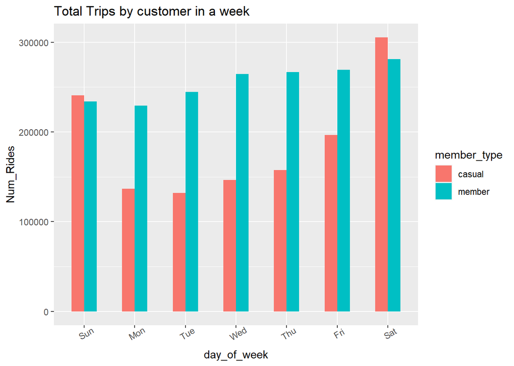

```r
Trips%>%
  group_by(member_type,day_of_week)%>%
  summarize(Num_Rides=n())%>%
  ggplot(aes(x=day_of_week,y=Num_Rides,fill=member_type))+
  theme(axis.text.x=element_text(angle=30))+
  labs(title="Total Trips by customer in a week")+
  geom_col(width=0.5, position=position_dodge(width=0.5))+
  scale_y_continuous(labels=function(x) format(x,scientific=FALSE))
```

## In which month do customers ride the most?

```r
month=Trips%>%
  group_by(member_type,month)%>%
  select(member_type,month,ride_length)%>%
  summarize(Num_Rides=n(),average_ride=mean(ride_length))%>%
  arrange(member_type,month)
month
```

```
## # A tibble: 18 × 4
## # Groups:   member_type [2]
##    member_type month Num_Rides average_ride
##    <chr>       <ord>     <int> <drtn>
##  1 casual      Apr       23605 73.14255 mins
##  2 casual      May       86838 51.22108 mins
##  3 casual      Jun      154536 51.67146 mins
##  4 casual      Jul      268663 59.95475 mins
##  5 casual      Aug      288586 44.93976 mins
##  6 casual      Sep      230049 38.22331 mins
##  7 casual      Oct      144511 30.26893 mins
##  8 casual      Nov       87902 31.84320 mins
##  9 casual      Dec       29994 26.85229 mins
## 10 member      Apr       61112 21.48034 mins
## 11 member      May      113252 19.77340 mins
## 12 member      Jun      187968 18.73320 mins
## 13 member      Jul      281002 17.76842 mins
## 14 member      Aug      330895 16.83624 mins
## 15 member      Sep      300718 15.54198 mins
## 16 member      Oct      242191 14.05165 mins
## 17 member      Nov      170921 13.59875 mins
## 18 member      Dec      101137 12.74999 mins
```

## Data Visualizations of which month do customers ride the most.

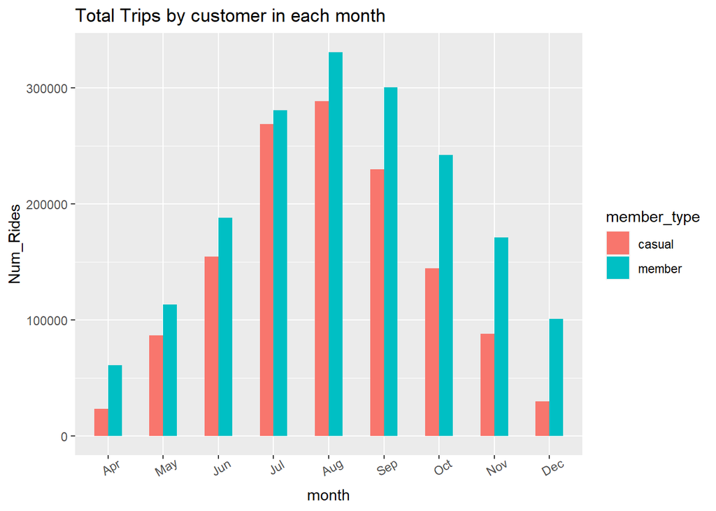

```r
Trips%>%
  group_by(member_type,month)%>%
  summarize(Num_Rides=n())%>%
  ggplot(aes(x=month,y=Num_Rides,fill=member_type))+
  theme(axis.text.x=element_text(angle=30))+
  labs(title="Total Trips by customer in each month")+
  geom_col(width=0.5, position=position_dodge(width=0.5))+
  scale_y_continuous(labels=function(x) format(x,scientific=FALSE))
```

During the peak of summer months, casual and paid member ride the most. After the summer season is over, number of rides for casual and paid member decrease significantly. And also, average number of rides also decrease after the summer is over.

## What kinds of ride do customer like the most?

```r
Type=Trips%>%
  group_by(member_type,rideable_type)%>%
  select(member_type,rideable_type,ride_length)%>%
  summarize(Num_Rides=n(),average_ride=mean(ride_length))%>%
  arrange(member_type,-Num_Rides)
Type
```

```
## # A tibble: 6 × 4
## # Groups:   member_type [2]
##   member_type rideable_type Num_Rides average_ride
##   <chr>       <chr>             <int> <drtn>
## 1 casual      docked_bike     1094267 50.42243 mins
## 2 casual      electric_bike    209098 21.68765 mins
## 3 casual      classic_bike      11319 26.29597 mins
## 4 member      docked_bike     1434532 17.13272 mins
## 5 member      electric_bike    295369 13.42870 mins
## 6 member      classic_bike      59295 13.22546 mins
```

## Data visualizations for what kinds of ride do customer like the most.

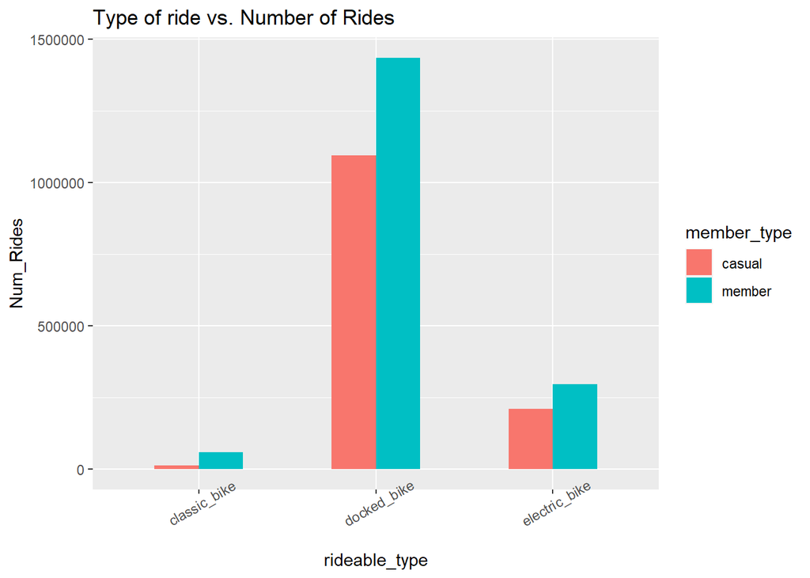

```r
Trips%>%
  group_by(member_type,rideable_type)%>%
  summarize(Num_Rides=n())%>%
  ggplot(aes(x=rideable_type,y=Num_Rides,fill=member_type))+
  labs(title="Type of ride vs. Number of Rides")+
  theme(axis.text.x=element_text(angle=30))+
  geom_col(width=0.5, position=position_dodge(width=0.5))+
  scale_y_continuous(labels=function(x) format(x,scientific=FALSE))
```